# Python Libraries Interactive Notebook

Today, we will be learning about four fundamental python libraries. These are widely used and plenty of documentation can be found online. Don't be afraid to search Google/Stack Overflow!

**These are the solutions! To work on the interactive notebook yourself, click here: Python_Libraries_Workshop.ipynb.**

1. Numpy: https://docs.scipy.org/doc/numpy-dev/user/index.html
2. Pandas: http://pandas.pydata.org/pandas-docs/stable/
3. Matplotlib: https://matplotlib.org/2.1.2/index.html
4. Seaborn: https://seaborn.pydata.org/

I. Numpy  
II. Pandas  
III. Plot with Pandas  
IV. Matplotlib  
V. Seaborn

### Jupyter Notebook Recap

`To run a cell: select cell, press SHIFT + ENTER`

The last line of a cell is always displayed

```python
"this will NOT be displayed"
"this will be displayed"
```

```
'this will be displayed'
```

If cells contain `...` we expect you to replace `...` with your code :)

## Import

`numpy`, `pandas`, `matplotlib`, and `seaborn` are made by other people! We need to `import` these modules in order to use them.

```python
import numpy as np
import matplotlib.pyplot as plt
import pandas as pd
import seaborn as sns
# %matplotlib inline
# sns.set()
```

# Numpy

[figure not shown]

Numpy's main use is ```np.array```  
Numpy arrays take less space than built-in lists and come with a **wide variety of useful functions.**

```python
# make an array
a = np.array([2,3,4])
a
```

```
array([2, 3, 4])
```

```python
# make a 2-dimensional array (matrix)
matrix = np.array([ [1,2,3],
                    [4,5,6],
                    [7,8,9] ])
matrix
```

```
array([[1, 2, 3],
       [4, 5, 6],
       [7, 8, 9]])
```

Linear Algebra!

```python
# you can multiply matrices with np.dot
np.dot(matrix, a)
```

```
array([20, 47, 74])
```

### Arithmetic with numpy!

**You can add/subtract/multiply/divide with numpy arrays!** You *cannot* do this with built-in python lists.

```python
a + 5
```

```
array([7, 8, 9])
```

```python
a * -1
```

```
array([-2, -3, -4])
```

```python
b = np.array([3, 2, 1])
a + b
```

```
array([5, 5, 5])
```

If you try to perform operations on two arrays of different lengths, an error will occur. Try running the following cell!

```python
# Run me!
b + np.array([1, 2, 3, 4])
```

```
---------------------------------------------------------------------------
ValueError                                Traceback (most recent call last)
<ipython-input-10-01af955792b6> in <module>()
      1 # Run me!
----> 2 b + np.array([1, 2, 3, 4])

ValueError: operands could not be broadcast together with shapes (3,) (4,)
```

Use `len( array )` to find length of array.

```python
len(b)
```

```
3
```

```python
len(np.array([1, 2, 3, 4]))
```

```
4
```

Conditionals apply to every element of a numpy array as well. This will come in handy later!

```python
a = np.array([1, 2, 3, 1, 1])
a == 1
```

```
array([ True, False, False,  True,  True], dtype=bool)
```

### Essential array functions

Why do we use Numpy? **Numpy provides a multitude of useful functions for arrays.** We'll teach you a few (many more exist!)

Exercise: Search online how to find the mean of a numpy array.

```python
x = np.array([1, 5, -7, 18, 1, -2, 4])
```

```python
# Find the mean of array x
x_mean = np.mean(x)
```

Here, we'll give you a list of some useful numpy functions. Remember, you can easily find info about these by searching google / numpy documentation!

```python
np.sum(x)
```

```
20
```

```python
np.min(x)
```

```
-7
```

```python
np.max(x)
```

```
18
```

```python
np.median(x)
```

```
1.0
```

```python
np.cumsum(x)
```

```
array([ 1,  6, -1, 17, 18, 16, 20])
```

```python
np.abs(x)
```

```
array([ 1,  5,  7, 18,  1,  2,  4])
```

What do you think `np.cumsum` does? Note, numpy has a similar function `np.cumprod`. Try it!

What do you think `np.diff` does?

```python
np.diff(x)
```

```
array([  4, -12,  25, -17,  -3,   6])
```

Two super useful functions in numpy are `np.arange` and `np.linspace`. They allow you to craft arrays with equidistant values:

- np.arange asks for [`start`], `stop`, and [`step`]
- np.linspace asks for `start`, `stop`, and `num`

```python
np.arange(0, 100, 10)
```

```
array([ 0, 10, 20, 30, 40, 50, 60, 70, 80, 90])
```

```python
np.linspace(0, 100, 15)
```

```
array([   0.        ,    7.14285714,   14.28571429,   21.42857143,
         28.57142857,   35.71428571,   42.85714286,   50.        ,
         57.14285714,   64.28571429,   71.42857143,   78.57142857,
         85.71428571,   92.85714286,  100.        ])
```

### Python

Using `np.arrays` in python is a little bit different than with built-in lists.

```python
a = np.array([2, 3, 4])
b = [2, 3, 4]
print(a)
print(b)
```

```
[2 3 4]
[2, 3, 4]
```

#### Adding values to np.array is different

```python
b.append("hello")
b
```

```
[2, 3, 4, 'hello']
```

```python
a = np.append(a, 'hello')
a
```

```
array(['2', '3', '4', 'hello'],
      dtype='<U21')
```

#### For loops work the same way

```python
c = np.array([1, 2, 3, 4, 5])
cumulative_product = 1

for element in c:
    cumulative_product *= element

cumulative_product
```

```
120
```

### Numpy Exercises

Use [`np.arange`](https://docs.scipy.org/doc/numpy/reference/generated/numpy.arange.html) to create an array called `arr1` that contains every odd number from 1 to 100, inclusive.

```python
arr1 = np.arange(1, 100, 2)
arr1
```

```
array([ 1,  3,  5,  7,  9, 11, 13, 15, 17, 19, 21, 23, 25, 27, 29, 31, 33,
       35, 37, 39, 41, 43, 45, 47, 49, 51, 53, 55, 57, 59, 61, 63, 65, 67,
       69, 71, 73, 75, 77, 79, 81, 83, 85, 87, 89, 91, 93, 95, 97, 99])
```

Use `arr1` to create an array `arr2` of every number divisible by 4 from 1 to 200, inclusive.

```python
arr2 = (arr1 + 1) * 2
arr2
```

```
array([  4,   8,  12,  16,  20,  24,  28,  32,  36,  40,  44,  48,  52,
        56,  60,  64,  68,  72,  76,  80,  84,  88,  92,  96, 100, 104,
       108, 112, 116, 120, 124, 128, 132, 136, 140, 144, 148, 152, 156,
       160, 164, 168, 172, 176, 180, 184, 188, 192, 196, 200])
```

Create the same array, but using [`np.linspace`](https://docs.scipy.org/doc/numpy/reference/generated/numpy.linspace.html) instead. Call this array `arr3`.

```python
arr3 = np.linspace(4, 200, 50)
arr3
```

```
array([   4.,    8.,   12.,   16.,   20.,   24.,   28.,   32.,   36.,
         40.,   44.,   48.,   52.,   56.,   60.,   64.,   68.,   72.,
         76.,   80.,   84.,   88.,   92.,   96.,  100.,  104.,  108.,
        112.,  116.,  120.,  124.,  128.,  132.,  136.,  140.,  144.,
        148.,  152.,  156.,  160.,  164.,  168.,  172.,  176.,  180.,
        184.,  188.,  192.,  196.,  200.])
```

Print the following summary statistics for `arr3`:

- minimum
- 1st quartile (Hint: See [`np.percentile()`](https://docs.scipy.org/doc/numpy-dev/reference/generated/numpy.percentile.html))
- median
- mean
- standard deviation
- 3rd quartile
- max

```python
print('Minimum: '            + str(np.min(arr3)))
print('1st quartile: '       + str(np.percentile(arr3, 25)))
print('Median: '             + str(np.median(arr3)))
print('Mean: '               + str(np.mean(arr3)))
print('Standard Deviation: ' + str(np.std(arr3)))
print('3rd Quartile: '       + str(np.percentile(arr3, 75)))
print('Max: '                + str(np.max(arr3)))
```

```
Minimum: 4.0
1st quartile: 53.0
Median: 102.0
Mean: 102.0
Standard Deviation: 57.7234787586
3rd Quartile: 151.0
Max: 200.0
```

# Pandas

[figure not shown]

Pandas is all about tables!

A table is called a ['dataframe'](http://pandas.pydata.org/pandas-docs/stable/dsintro.html#dataframe) in Pandas. Consider the table `fruit_info`:

| **color** | **fruit** |
| --- | --- |
| red | apple |
| orange | orange |
| yellow | banana |
| pink | raspberry |

## Pandas Series

Let's break this table down. DataFrames consist of columns called **`Series`**. Series act like numpy arrays.

*How to make a Series:*

1. create a numpy `array`
2. call `pd.Series(array, name="...")` # name can be anything

Exercise: Make a Series that contains the colors from `fruit_info` and has `name='color'`

```python
array = np.array(['red', 'orange', 'yellow', 'pink'])
color_column = pd.Series(array, name="color")
color_column
```

```
0       red
1    orange
2    yellow
3      pink
Name: color, dtype: object
```

Exercise: Make another Series for the fruit column:

```python
array = np.array(['apple', 'orange', 'banana', 'raspberry'])
fruit_column = pd.Series(array, name="fruit")
fruit_column
```

```
0        apple
1       orange
2       banana
3    raspberry
Name: fruit, dtype: object
```

Combine your Series into a table!

`pd.concat([ series1, series2, series3, ... ], 1)`

Don't forget the `1` or you'll just make a giant Series.

```python
fruit_info = pd.concat([color_column, fruit_column], 1)
fruit_info
```

|  | color | fruit |
| --- | --- | --- |
| 0 | red | apple |
| 1 | orange | orange |
| 2 | yellow | banana |
| 3 | pink | raspberry |

What if we were given the DataFrame and we want to extract the columns?

```python
fruit_info['fruit'] # we get the fruit_column Series back!
```

```
0        apple
1       orange
2       banana
3    raspberry
Name: fruit, dtype: object
```

### Dictionaries

Also, we can manually create tables by using a [python dictionary](https://www.python-course.eu/dictionaries.php). A dictionary has the following format:

```
d = { "name of column"   :  [  list of values  ],
      "name of column 2" :  [  list of values  ],
                        ...
                        ...
    }
```

```python
d = { 'fruit' : ['apple', 'orange', 'banana', 'raspberry'],
      'color' : ['red', 'orange', 'yellow', 'pink']
    }
```

```python
fruit_info_again = pd.DataFrame(d)
fruit_info_again
```

|  | color | fruit |
| --- | --- | --- |
| 0 | red | apple |
| 1 | orange | orange |
| 2 | yellow | banana |
| 3 | pink | raspberry |

### Add Columns

Add a column to `table` labeled "new column" like so:

`table['new column'] = array`

```python
fruit_info['inventory'] = np.array([23, 18, 50, 20])
fruit_info
```

|  | color | fruit | inventory |
| --- | --- | --- | --- |
| 0 | red | apple | 23 |
| 1 | orange | orange | 18 |
| 2 | yellow | banana | 50 |
| 3 | pink | raspberry | 20 |

Exercise: Add a column called `rating` that assigns your rating from 1 to 5 for each fruit :)

```python
fruit_info['rating'] = np.array([3, 4, 5, 5])

fruit_info  # should now include a rating column
```

|  | color | fruit | inventory | rating |
| --- | --- | --- | --- | --- |
| 0 | red | apple | 23 | 3 |
| 1 | orange | orange | 18 | 4 |
| 2 | yellow | banana | 50 | 5 |
| 3 | pink | raspberry | 20 | 5 |

### Drop

Exercise: Now, use the `.drop()` method to [drop](https://pandas.pydata.org/pandas-docs/stable/generated/pandas.DataFrame.drop.html) the `color` column.

```python
fruit_info_without_color = fruit_info.drop('color', 1) # must include axis=1

fruit_info_without_color
```

|  | fruit | inventory | rating |
| --- | --- | --- | --- |
| 0 | apple | 23 | 3 |
| 1 | orange | 18 | 4 |
| 2 | banana | 50 | 5 |
| 3 | raspberry | 20 | 5 |

## California Baby Names

Time to use a real dataset!

You can read a `.csv` file into pandas using `pd.read_csv( url )`.

Create a variable called `baby_names` that loads this data: `https://raw.githubusercontent.com/carlocrza/Data_Science_Society/master/ca_baby_names.csv`

```python
baby_names = pd.read_csv("https://raw.githubusercontent.com/carlocrza/Data_Science_Society/master/baby_names.csv")
```

Let's display the table. We can just type `baby_names` and run the cell but baby_names is HUGE! So, let's display just the first five rows with:

`DataFrame.head( # of rows )`

```python
baby_names.head(5)
```

|  | State | Sex | Year | Name | Count |
| --- | --- | --- | --- | --- | --- |
| 0 | CA | F | 1910 | Mary | 295 |
| 1 | CA | F | 1910 | Helen | 239 |
| 2 | CA | F | 1910 | Dorothy | 220 |
| 3 | CA | F | 1910 | Margaret | 163 |
| 4 | CA | F | 1910 | Frances | 134 |

## Row, Column Selection

Follow the structure:

`table.loc[rows, columns]`

`table.loc[2:8, [ 'Name', 'Count']]`

The above code will select columns "Name" and "Count" from rows 2 **through** 8.

```python
# Returns the name of our columns
baby_names.columns
```

```
Index(['State', 'Sex', 'Year', 'Name', 'Count'], dtype='object')
```

```python
baby_names.loc[2:8, ['Name', "Count"]]
```

|  | Name | Count |
| --- | --- | --- |
| 2 | Dorothy | 220 |
| 3 | Margaret | 163 |
| 4 | Frances | 134 |
| 5 | Ruth | 128 |
| 6 | Evelyn | 126 |
| 7 | Alice | 118 |
| 8 | Virginia | 101 |

Exercise: Return a table that includes rows 1000-1005 and only includes the column "Name".

```python
baby_names.loc[1000:1005, ['Name']]
```

|  | Name |
| --- | --- |
| 1000 | Sara |
| 1001 | Teresa |
| 1002 | Cecilia |
| 1003 | Eda |
| 1004 | Etta |
| 1005 | Faye |

```python
# Want to select EVERY row?
# Don't put anything before and after the colon :
baby_names.loc[:, ['Sex', 'Name']].head(4)
```

|  | Sex | Name |
| --- | --- | --- |
| 0 | F | Mary |
| 1 | F | Helen |
| 2 | F | Dorothy |
| 3 | F | Margaret |

### Selecting an entire Column

Remember we can extract the column in the form of a **Series** using:

`table_name['Name of column']`

```python
name_column = baby_names['Name']
name_column.head(5) # we can also use .head with Series!
```

```
0        Mary
1       Helen
2     Dorothy
3    Margaret
4     Frances
Name: Name, dtype: object
```

### Selecting rows with a Boolean Array

Lastly, we can select rows based off of True / False data. Let's go back to the simpler `fruit_info` table.

```python
fruit_info
```

|  | color | fruit | inventory | rating |
| --- | --- | --- | --- | --- |
| 0 | red | apple | 23 | 3 |
| 1 | orange | orange | 18 | 4 |
| 2 | yellow | banana | 50 | 5 |
| 3 | pink | raspberry | 20 | 5 |

```python
# select row only if corresponding value in *selection* is True
selection = np.array([True, False, True, False])
fruit_info[selection]
```

|  | color | fruit | inventory | rating |
| --- | --- | --- | --- | --- |
| 0 | red | apple | 23 | 3 |
| 2 | yellow | banana | 50 | 5 |

## Filtering Data

So far we have selected data based off of row numbers and column headers. Let's work on filtering data more precisely.

`table[condition]`

```python
condition = baby_names['Name'] == 'Carlo'
baby_names[condition].head(5)
```

|  | State | Sex | Year | Name | Count |
| --- | --- | --- | --- | --- | --- |
| 219486 | CA | M | 1917 | Carlo | 10 |
| 219941 | CA | M | 1918 | Carlo | 8 |
| 220848 | CA | M | 1920 | Carlo | 10 |
| 221935 | CA | M | 1922 | Carlo | 9 |
| 222457 | CA | M | 1923 | Carlo | 10 |

The above code only selects rows that have Name equal to 'Carlo'. Change it to your name!

### Apply multiple conditions!

`table[ (condition 1) & (condition 2) ]`

Class Exercise: select the names in Year 2000 that have larger than 3000 counts.

```python
result = baby_names[(baby_names['Count'] > 3000) & (baby_names['Year'] == 2000)]
result.head(3)
```

|  | State | Sex | Year | Name | Count |
| --- | --- | --- | --- | --- | --- |
| 320198 | CA | M | 2000 | Daniel | 4339 |
| 320199 | CA | M | 2000 | Anthony | 3837 |
| 320200 | CA | M | 2000 | Jose | 3803 |

### Thorough explanation:

Remember that calling `baby_names['Name']` returns a **Series** of all of the names.

Checking if values in the series are equal to `Carlo` results in an array of {True, False} values.

Then, we select rows based off of this boolean array. Thus, we could also do:

```python
names = baby_names['Name']
equalto_Carlo = (names == 'Carlo')  # equalto_Carlo is now an array of True/False variables!
baby_names[equalto_Carlo].head(5)
```

|  | State | Sex | Year | Name | Count |
| --- | --- | --- | --- | --- | --- |
| 219486 | CA | M | 1917 | Carlo | 10 |
| 219941 | CA | M | 1918 | Carlo | 8 |
| 220848 | CA | M | 1920 | Carlo | 10 |
| 221935 | CA | M | 1922 | Carlo | 9 |
| 222457 | CA | M | 1923 | Carlo | 10 |

## Using Numpy with Pandas

How many rows does our `baby_names` table have?

```python
len(baby_names)
```

```
367931
```

That's a lot of rows! We can't just look at the table and understand it.

Luckily, **Numpy** functions treat pandas **Series** as np.arrays.

Exercise: What is oldest and most recent year that we have data from in `baby_names`? HINT: np.min, np.max

```python
recent_year = np.max(baby_names['Year'])
oldest_year = np.min(baby_names['Year'])
(recent_year, oldest_year)
```

```
(2016, 1910)
```

Exercise: How many baby names were born in CA in 2015?

Hint: the 'Count' column refers the the number of occurrences of a baby name. How could we find the total number of baby names? Now narrow that to only 2015.

```python
baby_names_2015 = baby_names[baby_names['Year'] == 2015]
baby_names_2015_counts = baby_names_2015['Count']
number_baby_names_2015 = np.sum(baby_names_2015_counts)
number_baby_names_2015
```

```
429730
```

```python
np.sum(baby_names[baby_names['Year'] == 2015]['Count'])
```

```
429730
```

### np.unique

```python
# return an array with an element for each unique value in the Series/np.array
np.unique(baby_names['Sex'])
```

```
array(['F', 'M'], dtype=object)
```

```python
# demo
states = np.unique(baby_names['State']) # okay now we know this dataset only involves California babies.
```

```python
names = np.unique(baby_names['Name'])
len(names)
```

```
19234
```

## Copy vs View

Depending on how you format your code, pandas might be returning a copy of the dataframe (i.e. a whole new dataframe, but just with the same values), or a view of the dataframe (i.e. the same dataframe itself).

```python
carlos_fruits = fruit_info.copy()
carlos_fruits
```

|  | color | fruit | inventory | rating |
| --- | --- | --- | --- | --- |
| 0 | red | apple | 23 | 3 |
| 1 | orange | orange | 18 | 4 |
| 2 | yellow | banana | 50 | 5 |
| 3 | pink | raspberry | 20 | 5 |

Let's say Carlo is happy with those ratings. But Jun Seo loves bananas! Let's make a "new" dataframe and change the ratings accordingly:

```python
junseos_fruits = carlos_fruits
junseos_fruits['rating'] = [3, 4, 9999, 5]
junseos_fruits
```

|  | color | fruit | inventory | rating |
| --- | --- | --- | --- | --- |
| 0 | red | apple | 23 | 3 |
| 1 | orange | orange | 18 | 4 |
| 2 | yellow | banana | 50 | 9999 |
| 3 | pink | raspberry | 20 | 5 |

And taking a look back at Carlo's fruits:

```python
carlos_fruits
```

|  | color | fruit | inventory | rating |
| --- | --- | --- | --- | --- |
| 0 | red | apple | 23 | 3 |
| 1 | orange | orange | 18 | 4 |
| 2 | yellow | banana | 50 | 9999 |
| 3 | pink | raspberry | 20 | 5 |

Wait, Carlo's banana rating shouldn't be that high! What happened is that junseos_fruits returned a *view* on Carlo's dataframe. Then did our shenanigans affect the original fruit_info dataframe too?

```python
fruit_info
```

|  | color | fruit | inventory | rating |
| --- | --- | --- | --- | --- |
| 0 | red | apple | 23 | 3 |
| 1 | orange | orange | 18 | 4 |
| 2 | yellow | banana | 50 | 5 |
| 3 | pink | raspberry | 20 | 5 |

No, because when we called `carlos_fruits = fruit_info.copy()`, we asked pandas to forcibly create a brand new dataframe with identical values instead.

### SettingWithCopyWarning

This is arguably one of the most frustrating warnings you will see while using pandas. TL;DR: Use .loc instead of square brackets to index into data.

Let's say Jun Seo strongly dislikes apples.

```python
junseos_fruits[junseos_fruits['fruit'] == 'apple']
```

|  | color | fruit | inventory | rating |
| --- | --- | --- | --- | --- |
| 0 | red | apple | 23 | 3 |

```python
junseos_fruits[junseos_fruits['fruit'] == 'apple']['rating'] = -100
junseos_fruits
```

|  | color | fruit | inventory | rating |
| --- | --- | --- | --- | --- |
| 0 | red | apple | 23 | 3 |
| 1 | orange | orange | 18 | 4 |
| 2 | yellow | banana | 50 | 9999 |
| 3 | pink | raspberry | 20 | 5 |

```python
junseos_fruits['rating']
```

```
0       3
1       4
2    9999
3       5
Name: rating, dtype: int64
```

```python
junseos_fruits['rating'][0] = -100
junseos_fruits
```

|  | color | fruit | inventory | rating |
| --- | --- | --- | --- | --- |
| 0 | red | apple | 23 | -100 |
| 1 | orange | orange | 18 | 4 |
| 2 | yellow | banana | 50 | 9999 |
| 3 | pink | raspberry | 20 | 5 |

```python
junseos_fruits.loc[1, 'rating'] = 1738
junseos_fruits
```

|  | color | fruit | inventory | rating |
| --- | --- | --- | --- | --- |
| 0 | red | apple | 23 | -100 |
| 1 | orange | orange | 18 | 1738 |
| 2 | yellow | banana | 50 | 9999 |
| 3 | pink | raspberry | 20 | 5 |

## [optional] Group By

We won't have time to go through this thoroughly in lab. However, we encourage you to look into this material if you want to go further. Feel free to ask us any questions!

In the previous section we calculated the number of baby names registered in 2015.

```python
np.sum(baby_names[baby_names['Year'] == 2015]['Count'])
```

```
429730
```

There are 107 years though. If we wanted to know how many babies were born in California for each year we need to do something more efficient.

`groupby` to the rescue!

Groupby allows us to split our table into groups, each group having one similarity.

For example if we group by "Year" we would create 107 groups because there are 107 unique years.

`baby_names.groupby('Year')`

Now we have 107 groups but what do we do with them? We can apply the function `sum` to each group. This will sum the other numerical column, 'Counts' which reduces each group to a single row: Year and sum.

Excellent tutorial: http://bconnelly.net/2013/10/summarizing-data-in-python-with-pandas/

```python
# this will apply sum to the "Count" column of each year group
yearly_data = baby_names.groupby('Year').sum()
yearly_data.head(5)
```

| Year | Count |
| --- | --- |
| 1910 | 9164 |
| 1911 | 9984 |
| 1912 | 17944 |
| 1913 | 22094 |
| 1914 | 26925 |

Further reading: http://bconnelly.net/2013/10/summarizing-data-in-python-with-pandas/

# Plot with Pandas

```python
%matplotlib inline
```

[Pandas.plot documentation](https://pandas.pydata.org/pandas-docs/stable/generated/pandas.DataFrame.plot.html)

Pandas comes with a built-in `plot` method that can be very useful! `pandas.plot` actually uses `matplotlib` behind the scenes!

`yearly_data` contains the number of registered babies per year.

```python
yearly_data.head()
```

| Year | Count |
| --- | --- |
| 1910 | 9164 |
| 1911 | 9984 |
| 1912 | 17944 |
| 1913 | 22094 |
| 1914 | 26925 |

## Line Graphs

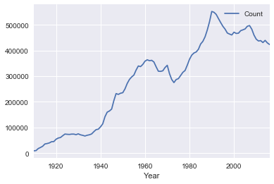

```python
yearly_data.plot(kind="line")  #kind='line' is optional
```

### Study: Name History

```python
# don't worry about this function unless you want to learn about groupby
def your_name_history(name):
    return baby_names[baby_names['Name'] == name].groupby('Year').sum()
```

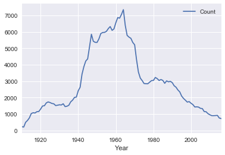

```python
table = your_name_history('John')

table.plot()
```

## Bar Graphs

We can modify our data before we graph it to analyze different things.

```
(-0.5, 106.5, 0.0, 580000.05000000005)
```

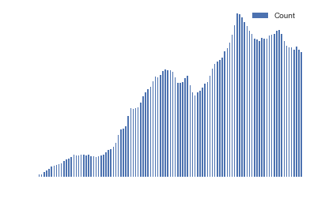

```python
yearly_data.plot(kind="bar")
plt.axis('off')
```

Class Exercise: How could we graph only the 15 years after World War II (i.e. 1945-1960)?

Hint: create a table with only the desired years first

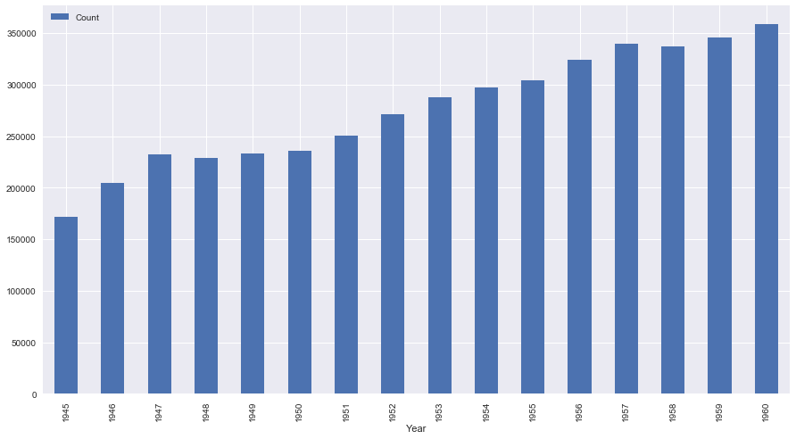

```python
modified = yearly_data.loc[1945:1960]

modified.plot(kind="bar", figsize=(15,8))
```